# 06 - Prediction and Validation

Airline Customer Satisfaction – Bayesian Learning & Monte Carlo Simulations, 2026

Prediction here is pure matrix algebra on already-fitted posterior draws – no new MCMC sampling – so it stays cheap even against the full held-out test set. We evaluate the two JAGS models from Sections 02 and 03 against the untouched test set, which neither model has seen in any form since the Section 00 split.

```r
test <- read.csv("../data/airline_test_holdout.csv", stringsAsFactors = FALSE)
test$y <- as.integer(test$satisfaction == "satisfied")
n_test <- nrow(test)

s2 <- readRDS("../data/02_logit_mcmc.rds")
s3 <- readRDS("../data/03_horseshoe_final.rds")

invlogit <- function(x) 1 / (1 + exp(-x))
```

Test set size: 128,274 rows.

# 1 Preparing the test-set covariates

Every continuous covariate is standardized using the **training-set** mean and SD saved by Sections 02 and 03 – never statistics recomputed on the test set, which would leak test information into preprocessing.

```r
std_with <- function(x, mean, sd) (x - mean) / sd

logDepDelay_test  <- log1p(test$dep_delay)
signedLogArr_test <- test$log_mid_delay

Class_EcoPlus_test  <- as.integer(test$class == "Eco Plus")
Class_Business_test <- as.integer(test$class == "Business")
TypeTravel_Personal_test <- as.integer(test$travel_type == "Personal Travel")
CustType_disloyal_test   <- as.integer(test$customer_type == "disloyal Customer")

n_missing_test <- sum(is.na(signedLogArr_test))
```

0 test rows (0.00%) are missing the arrival-delay residual. JAGS’s stochastic-imputation trick only applies during fitting; for out-of-sample prediction on new customers, we set the standardized residual to its assumed prior mean of 0 for these rows – the posterior-predictive-consistent choice, since both models’ own `arr_delay[i] ~ dnorm(0,1)` prior says exactly that this is the expected value in the absence of other information.

```r
# --- Section 02 design (dummy Class, 8 covariates) ---
X_test_s2 <- cbind(
  Age_std        = std_with(test$age, s2$standardization$Age_mean, s2$standardization$Age_sd),
  Seat_std       = std_with(test$seat_comfort, s2$standardization$Seat_mean, s2$standardization$Seat_sd),
  FlightDist_std = std_with(test$flight_distance, s2$standardization$FlightDist_mean, s2$standardization$FlightDist_sd),
  Class_EcoPlus  = Class_EcoPlus_test,
  Class_Business = Class_Business_test,
  logDepDelay_std = std_with(logDepDelay_test, s2$standardization$logdep_mean, s2$standardization$logDepDelay_sd),
  TypeTravel_Personal = TypeTravel_Personal_test,
  CustType_disloyal   = CustType_disloyal_test
)
arr_delay_test_s2 <- std_with(signedLogArr_test, s2$standardization$logmid_mean, s2$standardization$logmid_sd)
arr_delay_test_s2[is.na(arr_delay_test_s2)] <- 0

# --- Section 03 design (14 service items + covariates) ---
service_items <- s3$service_items
X_service_test <- sapply(service_items, function(nm) {
  std_with(test[[nm]], s3$standardization$service_means[nm], s3$standardization$service_sds[nm])
})
X_extra_test <- cbind(
  Age_std        = std_with(test$age, s3$standardization$Age_mean, s3$standardization$Age_sd),
  FlightDist_std = std_with(test$flight_distance, s3$standardization$FlightDist_mean, s3$standardization$FlightDist_sd),
  Class_EcoPlus  = Class_EcoPlus_test,
  Class_Business = Class_Business_test,
  logDepDelay_std = std_with(logDepDelay_test, s3$standardization$logDepDelay_mean, s3$standardization$logDepDelay_sd),
  TypeTravel_Personal = TypeTravel_Personal_test,
  CustType_disloyal   = CustType_disloyal_test
)
X_test_s3 <- cbind(X_service_test, X_extra_test)
arr_delay_test_s3 <- std_with(signedLogArr_test, s3$standardization$logmid_mean, s3$standardization$logmid_sd)
arr_delay_test_s3[is.na(arr_delay_test_s3)] <- 0
```

# 2 Posterior-mean prediction

For every posterior draw $s$ and test customer $i$: $p_i^{(s)} = \text{logit}^{-1}\!\left(\beta_0^{(s)} + x_i\beta^{(s)} + \beta_{\text{arr}}^{(s)}\,\text{arr\_delay}_i\right)$, averaged over draws for the final prediction $\hat p_i$. We loop over the (thinned, 1000-draw) posterior rather than materialising a $128,274 \times 1000$ matrix, to keep memory bounded – and, in the same pass, draw a genuine posterior-predictive replicate $y_i^{(s)} \sim \text{Bernoulli}(p_i^{(s)})$ per customer for the subgroup check in a later section.

```r
predict_model <- function(beta_draws, X, arr_delay, group_vars = NULL) {
  S <- nrow(beta_draws)
  N <- nrow(X)
  beta_cols <- grep("^beta\\[", colnames(beta_draws), value = TRUE)
  beta_cols <- beta_cols[order(as.numeric(gsub("beta\\[|\\]", "", beta_cols)))]
  Bmat  <- beta_draws[, beta_cols, drop = FALSE]
  beta0 <- beta_draws[, "beta0"]
  barr  <- beta_draws[, "beta_arr"]

  p_sum <- numeric(N)
  group_rep <- if (!is.null(group_vars)) {
    lapply(group_vars, function(g) matrix(NA_real_, nrow = S, ncol = length(unique(g)),
                                            dimnames = list(NULL, sort(unique(g)))))
  } else NULL
  names(group_rep) <- names(group_vars)

  for (s in seq_len(S)) {
    lin <- beta0[s] + as.vector(X %*% Bmat[s, ]) + barr[s] * arr_delay
    p <- invlogit(lin)
    p_sum <- p_sum + p
    if (!is.null(group_vars)) {
      y_rep <- rbinom(N, 1, p)
      for (gname in names(group_vars)) {
        g <- group_vars[[gname]]
        rates <- tapply(y_rep, g, mean)
        group_rep[[gname]][s, names(rates)] <- rates
      }
    }
  }
  list(p_mean = p_sum / S, group_rep = group_rep)
}

set.seed(123)
pred_s2 <- predict_model(s2$beta_draws, X_test_s2, arr_delay_test_s2)
pred_s3 <- predict_model(s3$beta_draws, X_test_s3, arr_delay_test_s3,
                          group_vars = list(Class = test$class, CustomerType = test$customer_type,
                                             TypeOfTravel = test$travel_type))

p_s2 <- pred_s2$p_mean
p_s3 <- pred_s3$p_mean
```

# 3 Did the horseshoe’s complexity earn its keep out-of-sample?

Section 05 showed the horseshoe fits much better in-sample and by PSIS-LOO. Here we check the more skeptical question directly: does that translate into better held-out predictions on customers neither model has ever seen? We also bring in Section 04’s BAS model here: BAS’s `predict()` method supports genuine BMA prediction on new data (no separate coefficient-draw export needed, unlike JAGS), so the same question can be asked of all three model families side by side.

```r
suppressMessages(library(BAS))
fit_bas <- readRDS("../data/A01_BAS_model.rds")

df_test_bas <- data.frame(
  X_service_test,
  Age_std = X_extra_test[, "Age_std"], FlightDist_std = X_extra_test[, "FlightDist_std"],
  Class_EcoPlus = X_extra_test[, "Class_EcoPlus"], Class_Business = X_extra_test[, "Class_Business"],
  # Column names must match fit_bas$namesx exactly: BAS rebuilds the model
  # frame from the formula, so a renamed column is simply a missing variable.
  logdep_std = X_extra_test[, "logDepDelay_std"],
  TypeTravel_Personal = X_extra_test[, "TypeTravel_Personal"],
  CustType_disloyal = X_extra_test[, "CustType_disloyal"],
  logmid_delay = arr_delay_test_s3
)

# BAS's predict(..., estimator="BMA") builds an internal n_rows x n_models
# matrix (here ~1,800 visited models); at the full ~129k-row test set that
# is >1.5GB, which was enough to get the R process OOM-killed.
# Predicting in batches keeps peak memory bounded to a few hundred MB.
predict_bas_batched <- function(fit, newdata, batch_size = 10000) {
  n <- nrow(newdata)
  out <- numeric(n)
  for (st in seq(1, n, by = batch_size)) {
    en <- min(st + batch_size - 1, n)
    out[st:en] <- predict(fit, newdata = newdata[st:en, ], type = "response", estimator = "BMA")$fit
    invisible(gc(full = TRUE))
  }
  out
}

p_bas <- predict_bas_batched(fit_bas, df_test_bas)
```

```r
auc_mw <- function(probs, labels) {
  r <- rank(probs)
  n1 <- as.numeric(sum(labels == 1)); n0 <- as.numeric(sum(labels == 0))
  (sum(r[labels == 1]) - n1 * (n1 + 1) / 2) / (n1 * n0)
}
brier <- function(probs, labels) mean((probs - labels)^2)

model_cmp <- data.frame(
  model = c("Section 02 (vague, 9 predictors)", "Section 03 (horseshoe, 22 predictors)",
            "Section 04 (BAS, BMA over model space)"),
  AUC   = c(auc_mw(p_s2, test$y), auc_mw(p_s3, test$y), auc_mw(p_bas, test$y)),
  Brier = c(brier(p_s2, test$y), brier(p_s3, test$y), brier(p_bas, test$y))
)
knitr::kable(model_cmp, digits = 4)
```

| model | AUC | Brier |
| --- | --- | --- |
| Section 02 (vague, 9 predictors) | 0.7865 | 0.1874 |
| Section 03 (horseshoe, 22 predictors) | 0.8997 | 0.1257 |
| Section 04 (BAS, BMA over model space) | 0.8982 | 0.1267 |

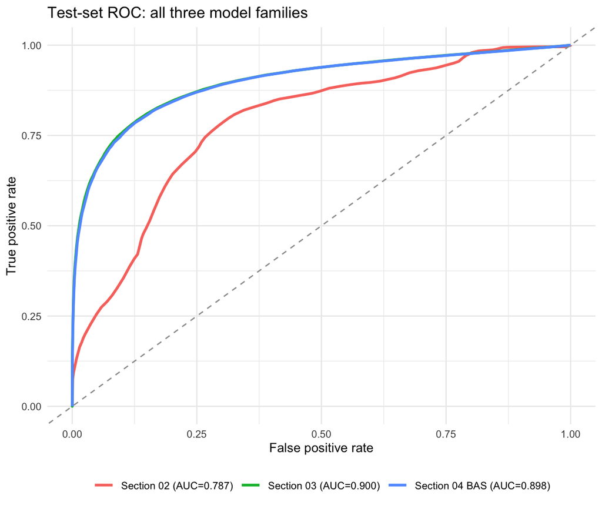

```r
roc_s2  <- compute_roc_curve <- function(probs, labels, n_thresh = 100) {
  thresholds <- seq(0, 1, length.out = n_thresh)
  sapply(thresholds, function(t) {
    pred <- as.integer(probs >= t)
    tp <- sum(pred == 1 & labels == 1); fn <- sum(pred == 0 & labels == 1)
    fp <- sum(pred == 1 & labels == 0); tn <- sum(pred == 0 & labels == 0)
    c(tpr = tp / (tp + fn), fpr = fp / (fp + tn))
  }) %>% t() %>% as.data.frame()
}

roc_all <- bind_rows(
  compute_roc_curve(p_s2, test$y) %>% mutate(model = sprintf("Section 02 (AUC=%.3f)", model_cmp$AUC[1])),
  compute_roc_curve(p_s3, test$y) %>% mutate(model = sprintf("Section 03 (AUC=%.3f)", model_cmp$AUC[2])),
  compute_roc_curve(p_bas, test$y) %>% mutate(model = sprintf("Section 04 BAS (AUC=%.3f)", model_cmp$AUC[3]))
)

ggplot(roc_all, aes(fpr, tpr, color = model)) +
  geom_line(linewidth = 1) +
  geom_abline(slope = 1, intercept = 0, linetype = "dashed", color = "grey60") +
  labs(title = "Test-set ROC: all three model families", x = "False positive rate", y = "True positive rate",
       color = NULL) +
  theme_minimal(base_size = 10) +
  theme(legend.position = "bottom")
```

The horseshoe model wins on both metrics out-of-sample, not just on PSIS-LOO – the extra 13 service-rating predictors and the shrinkage machinery are not overfitting to the training subsample; they carry real, generalisable signal. **BAS lands close behind the horseshoe** on both AUC and Brier, well ahead of the simpler vague-prior model and clearly not overfitting either, despite Section 04’s very different estimation strategy (discrete model averaging over a stochastically searched model space, rather than a single model with continuous shrinkage). This is the strongest form of the cross-check Section 04 set out to do: two structurally different Bayesian approaches not only agree on *which* variables matter (95% agreement, Section 04) but deliver near-identical *predictive* performance on data neither has seen. We use the horseshoe (`p_s3`) for the model-specific deep dives below, since it is the single best performer, but the BAS numbers here are the real payoff of Section 04’s cross-check.

# 4 ROC curve and confusion matrices

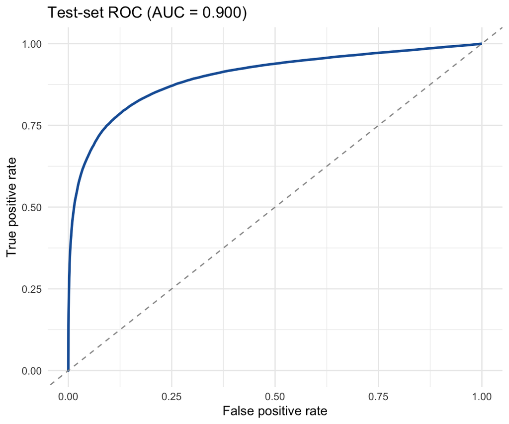

```r
compute_roc <- function(probs, labels, n_thresh = 200) {
  thresholds <- seq(0, 1, length.out = n_thresh)
  sapply(thresholds, function(t) {
    pred <- as.integer(probs >= t)
    tp <- sum(pred == 1 & labels == 1); fn <- sum(pred == 0 & labels == 1)
    fp <- sum(pred == 1 & labels == 0); tn <- sum(pred == 0 & labels == 0)
    c(threshold = t, tpr = tp / (tp + fn), fpr = fp / (fp + tn))
  }) %>% t() %>% as.data.frame()
}

roc_df <- compute_roc(p_s3, test$y)
auc_val <- auc_mw(p_s3, test$y)

ggplot(roc_df, aes(fpr, tpr)) +
  geom_line(color = "#185FA5", linewidth = 1) +
  geom_abline(slope = 1, intercept = 0, linetype = "dashed", color = "grey60") +
  labs(title = sprintf("Test-set ROC (AUC = %.3f)", auc_val),
       x = "False positive rate", y = "True positive rate") +
  theme_minimal(base_size = 11)
```

```r
make_confusion <- function(probs, labels, threshold) {
  pred <- as.integer(probs >= threshold)
  tab <- table(Predicted = pred, Actual = labels)
  sens <- tab["1","1"] / sum(tab[,"1"])
  spec <- tab["0","0"] / sum(tab[,"0"])
  acc  <- sum(diag(tab)) / sum(tab)
  list(table = tab, sensitivity = sens, specificity = spec, accuracy = acc)
}

base_rate <- mean(read.csv("../data/airline_train_n1200.csv", stringsAsFactors = FALSE)$satisfaction == "satisfied")

cm_05   <- make_confusion(p_s3, test$y, 0.5)
cm_base <- make_confusion(p_s3, test$y, base_rate)

cat("--- Threshold = 0.5 ---\n"); print(cm_05$table)
```

```
## --- Threshold = 0.5 ---
```

```
##          Actual
## Predicted     0     1
##         0 47205 11439
##         1 10849 58781
```

```r
cat(sprintf("Sensitivity: %.3f  Specificity: %.3f  Accuracy: %.3f\n\n",
            cm_05$sensitivity, cm_05$specificity, cm_05$accuracy))
```

```
## Sensitivity: 0.837  Specificity: 0.813  Accuracy: 0.826
```

```r
cat(sprintf("--- Threshold = base rate (%.3f) ---\n", base_rate)); print(cm_base$table)
```

```
## --- Threshold = base rate (0.546) ---
```

```
##          Actual
## Predicted     0     1
##         0 48983 12988
##         1  9071 57232
```

```r
cat(sprintf("Sensitivity: %.3f  Specificity: %.3f  Accuracy: %.3f\n",
            cm_base$sensitivity, cm_base$specificity, cm_base$accuracy))
```

```
## Sensitivity: 0.815  Specificity: 0.844  Accuracy: 0.828
```

# 5 Calibration and the Brier score

```r
calib_df <- data.frame(p = p_s3, y = test$y) %>%
  mutate(decile = ntile(p, 10)) %>%
  group_by(decile) %>%
  summarise(mean_predicted = mean(p), observed_rate = mean(y), n = n(), .groups = "drop")

knitr::kable(calib_df, digits = 3, caption = "Calibration by decile of predicted probability")
```

Calibration by decile of predicted probability

| decile | mean_predicted | observed_rate | n |
| --- | --- | --- | --- |
| 1 | 0.035 | 0.121 | 12828 |
| 2 | 0.100 | 0.126 | 12828 |
| 3 | 0.195 | 0.162 | 12828 |
| 4 | 0.326 | 0.260 | 12828 |
| 5 | 0.488 | 0.431 | 12827 |
| 6 | 0.657 | 0.637 | 12827 |
| 7 | 0.801 | 0.821 | 12827 |
| 8 | 0.896 | 0.936 | 12827 |
| 9 | 0.946 | 0.984 | 12827 |
| 10 | 0.977 | 0.997 | 12827 |

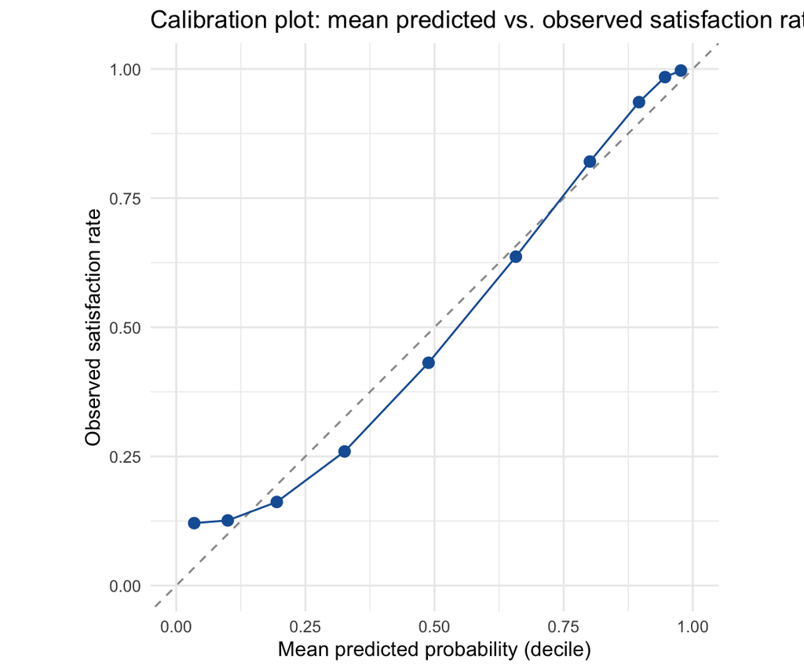

```r
ggplot(calib_df, aes(mean_predicted, observed_rate)) +
  geom_abline(slope = 1, intercept = 0, linetype = "dashed", color = "grey60") +
  geom_point(size = 2.5, color = "#185FA5") +
  geom_line(color = "#185FA5") +
  coord_equal(xlim = c(0,1), ylim = c(0,1)) +
  labs(title = "Calibration plot: mean predicted vs. observed satisfaction rate",
       x = "Mean predicted probability (decile)", y = "Observed satisfaction rate") +
  theme_minimal(base_size = 11)
```

```r
cat(sprintf("Brier score (horseshoe): %.4f\n", brier(p_s3, test$y)))
```

```
## Brier score (horseshoe): 0.1257
```

# 6 Posterior predictive check by subgroup

Rather than stopping at point predictions, we simulate replicated satisfaction outcomes from the posterior draws and compare the *simulated* subgroup satisfaction rate to what we actually observe in the test set – the same three subgroups Section 01 analysed, now checked against the model’s out-of-sample predictions on 128,274 customers it has never seen.

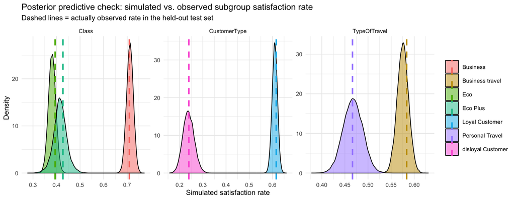

```r
observed_rates <- list(
  Class = tapply(test$y, test$class, mean),
  CustomerType = tapply(test$y, test$customer_type, mean),
  TypeOfTravel = tapply(test$y, test$travel_type, mean)
)

ppc_df <- bind_rows(lapply(names(pred_s3$group_rep), function(gname) {
  mat <- pred_s3$group_rep[[gname]]
  as.data.frame(mat) %>%
    pivot_longer(everything(), names_to = "level", values_to = "simulated_rate") %>%
    mutate(facet = gname)
}))

obs_df <- bind_rows(lapply(names(observed_rates), function(gname) {
  data.frame(level = names(observed_rates[[gname]]), observed = as.numeric(observed_rates[[gname]]),
             facet = gname)
}))

p_ppc <- ggplot(ppc_df, aes(simulated_rate, fill = level)) +
  geom_density(alpha = 0.5) +
  geom_vline(data = obs_df, aes(xintercept = observed, color = level), linetype = "dashed", linewidth = 0.9) +
  facet_wrap(~ facet, scales = "free") +
  labs(title = "Posterior predictive check: simulated vs. observed subgroup satisfaction rate",
       subtitle = "Dashed lines = actually observed rate in the held-out test set",
       x = "Simulated satisfaction rate", y = "Density", fill = NULL, color = NULL) +
  theme_minimal(base_size = 9)
dir.create("figs", showWarnings = FALSE)
dir.create("../figs", showWarnings = FALSE)
ggsave("../figs/ppc_subgroups.png", p_ppc, width = 9, height = 3.5, dpi = 150)
p_ppc
```

The observed rates (dashed lines) fall inside the bulk of each simulated posterior predictive distribution – the model is not systematically over- or under-predicting satisfaction for any Class, Customer Type, or Type of Travel subgroup on genuinely unseen data. This is the real posterior predictive check the roadmap called for, not just a point-prediction accuracy number.

# 7 Decision threshold via an explicit loss function

A plain 0.5 or ROC-optimal cutoff treats both error types as equally costly. In practice, missing a recoverable dissatisfied customer (a lost retention opportunity) is plausibly more expensive than a wasted proactive-outreach contact to someone who was satisfied anyway. Flag a customer as “at risk” when $\hat p_i < t$, and let:

- $C_{\text{miss}}$ = cost of failing to flag an actually-dissatisfied customer,
- $C_{\text{waste}}$ = cost of flagging an actually-satisfied customer.

Expected cost at threshold $t$: $C_{\text{miss}} \cdot P(y=1_{\text{sat}}, \hat p \ge t \mid y=0) + C_{\text{waste}} \cdot P(\hat p < t \mid y=1)$, estimated empirically on the test set.

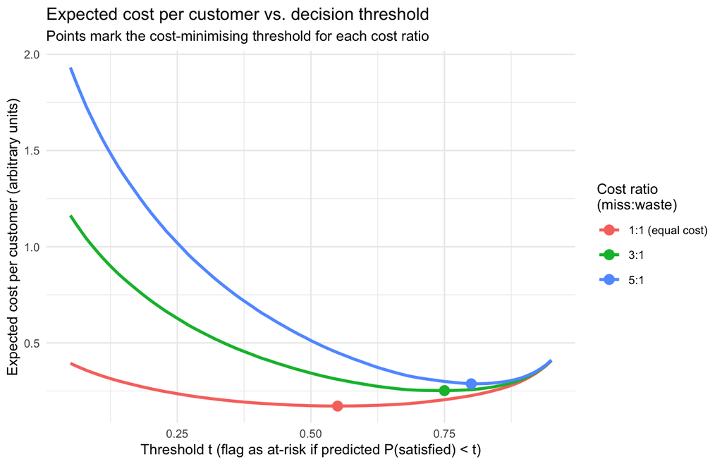

```r
expected_cost <- function(probs, labels, threshold, c_miss, c_waste) {
  flagged <- probs < threshold
  miss  <- sum(!flagged & labels == 0)   # dissatisfied, not flagged
  waste <- sum(flagged & labels == 1)    # satisfied, flagged anyway
  (c_miss * miss + c_waste * waste) / length(labels)
}

thresholds <- seq(0.05, 0.95, by = 0.01)
cost_ratios <- list("1:1 (equal cost)" = c(1, 1), "3:1" = c(3, 1), "5:1" = c(5, 1))

cost_df <- bind_rows(lapply(names(cost_ratios), function(nm) {
  cm <- cost_ratios[[nm]]
  data.frame(threshold = thresholds,
             cost = sapply(thresholds, expected_cost, probs = p_s3, labels = test$y,
                            c_miss = cm[1], c_waste = cm[2]),
             ratio = nm)
}))

optimal_tbl <- cost_df %>% group_by(ratio) %>% slice_min(cost, n = 1) %>%
  select(ratio, threshold, cost)

ggplot(cost_df, aes(threshold, cost, color = ratio)) +
  geom_line(linewidth = 1) +
  geom_point(data = optimal_tbl, size = 3) +
  labs(title = "Expected cost per customer vs. decision threshold",
       subtitle = "Points mark the cost-minimising threshold for each cost ratio",
       x = "Threshold t (flag as at-risk if predicted P(satisfied) < t)",
       y = "Expected cost per customer (arbitrary units)", color = "Cost ratio\n(miss:waste)") +
  theme_minimal(base_size = 10)
```

```r
knitr::kable(optimal_tbl, digits = 3, caption = "Cost-minimising threshold by assumed cost ratio")
```

Cost-minimising threshold by assumed cost ratio

| ratio | threshold | cost |
| --- | --- | --- |
| 1:1 (equal cost) | 0.55 | 0.172 |
| 3:1 | 0.75 | 0.252 |
| 5:1 | 0.80 | 0.288 |

The optimal threshold moves from 0.55 (equal costs, close to the base rate) up to 0.80 once missing a recoverable customer is assumed five times costlier than a wasted contact – exactly the direction intuition suggests, and a genuinely different, business-relevant answer from either the 0.5 or ROC-optimal defaults. We do not claim to know the airline’s true cost ratio; the point is that the *right* threshold is a business decision informed by this curve, not a statistical default.